# RMarkdown Analyse

2024-11-14

#question 2

```r
library(carData)
data("TitanicSurvival")
```

```r
df<-TitanicSurvival
summary(df)
```

```
##  survived      sex           age          passengerClass
##  no :809   female:466   Min.   : 0.1667   1st:323
##  yes:500   male  :843   1st Qu.:21.0000   2nd:277
##                         Median :28.0000   3rd:709
##                         Mean   :29.8811
##                         3rd Qu.:39.0000
##                         Max.   :80.0000
##                         NA's   :263
```

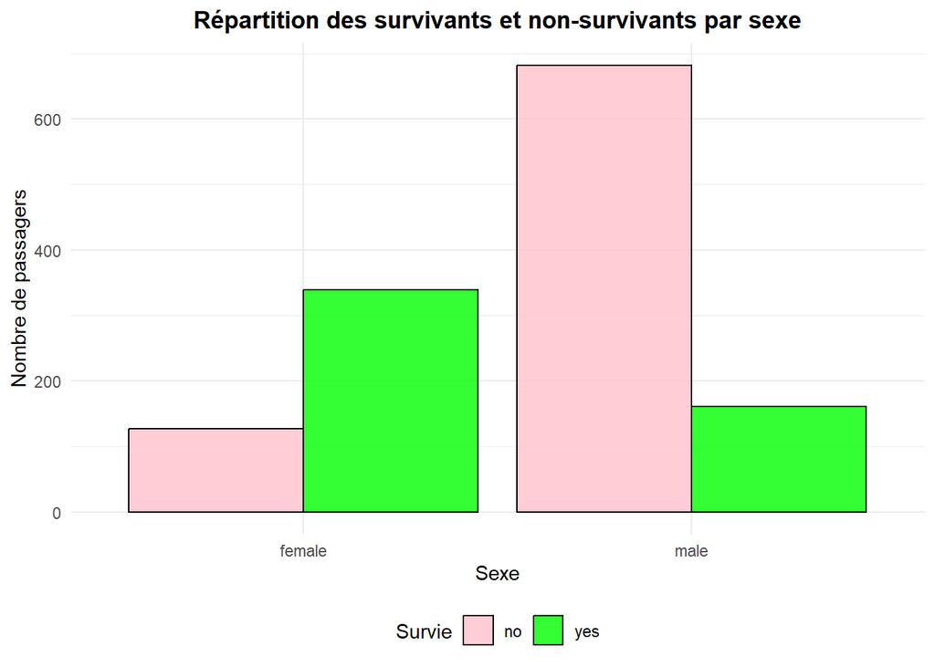

```r
library(ggplot2)
ggplot(TitanicSurvival, aes(x = sex, fill = survived)) +
  geom_bar(position = "dodge", color = "black", alpha = 0.8) +
  labs(
    title = "Répartition des survivants et non-survivants par sexe",
    x = "Sexe",
    y = "Nombre de passagers",
    fill = "Survie"
  ) +
  scale_fill_manual(values = c("no" = "pink", "yes" = "green")) +
  theme_minimal() +
  theme(
    plot.title = element_text(face = "bold", hjust = 0.5),
    legend.position = "bottom"
  )
```

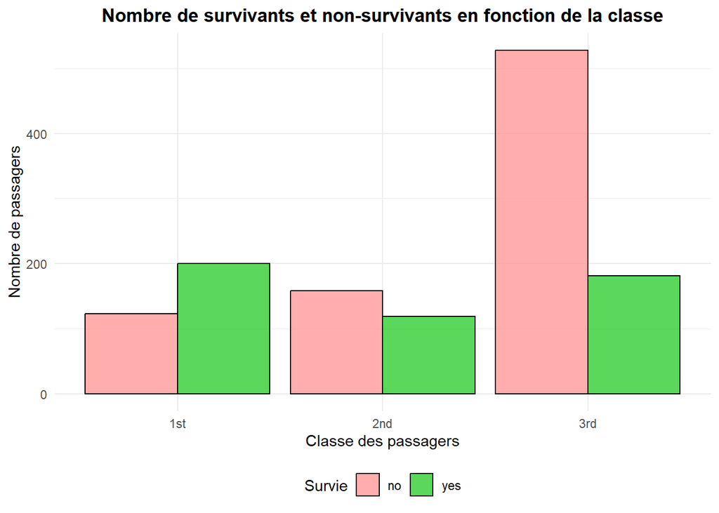

```r
library(ggplot2)
library(dplyr)
ggplot(TitanicSurvival, aes(x = passengerClass, fill = survived)) +
  geom_bar(position = "dodge", color = "black", alpha = 0.8) +
  labs(
    title = "Nombre de survivants et non-survivants en fonction de la classe",
    x = "Classe des passagers",
    y = "Nombre de passagers",
    fill = "Survie"
  ) +
  scale_fill_manual(values = c(
    "no" = "#FF9999",
    "yes" = "#32CD32"
  )) +
  theme_minimal() +
  theme(
    plot.title = element_text(face = "bold", hjust = 0.5),
    legend.position = "bottom"
  )
```

Ce graphique met en lumière les inégalités sociales dans les chances de survie lors du naufrage du Titanic. Les passagers de 1re classe ont eu un net avantage, avec un taux de survie élevé, illustré par une barre verte dominante. Ceux de 2e classe présentent des chances de survie plus équilibrées, tandis que les passagers de 3e classe, largement défavorisés, ont majoritairement péri, comme le montre la prédominance de la barre rose. Ce graphique reflète l’impact des disparités sociales sur les issues de cette tragédie.

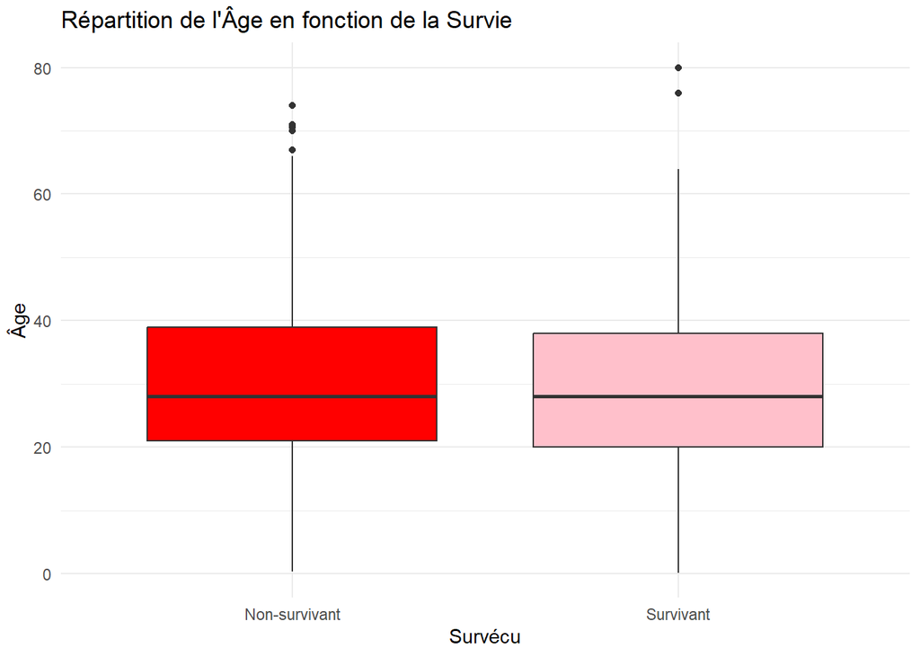

```r
data <- TitanicSurvival %>%
  na.omit() %>%
  mutate(survived = factor(survived, levels = c(0, 1), labels = c("Non-survivant", "Survivant")),
         sex = factor(sex, levels = c("male", "female")))

TitanicSurvival <- TitanicSurvival %>%
  filter(!is.na(survived) & !is.na(sex) & !is.na(passengerClass)) %>%
  mutate(
    survived = factor(survived, levels = c("no", "yes"), labels = c("Non-survivant", "Survivant")),  # Convertir 'survived' en facteur
    sex = factor(sex, levels = c("male", "female")),
    passengerClass = factor(passengerClass, levels = c("1st", "2nd", "3rd"))
  )

ggplot(TitanicSurvival, aes(x = survived, y = age, fill = survived)) +
  geom_boxplot() +
  labs(title = "Répartition de l'Âge en fonction de la Survie",
       x = "Survécu",
       y = "Âge") +
  scale_fill_manual(values = c("Non-survivant" = "red", "Survivant" = "pink")) +
  theme_minimal() +
  theme(legend.position = "none")
```

Ce graphique montre une répartition des âges similaire entre survivants et non-survivants, avec des médianes proches d’environ 30 ans. Les survivants incluent davantage d’enfants, tandis que les non-survivants sont principalement des adultes de 20 à 40 ans. Bien que l’âge ait eu un impact limité, il semble avoir été moins déterminant que le sexe ou la classe sociale dans les chances de survie

```r
y <- as.numeric(df$survived)-1
summary(glm(y~age+sex+passengerClass, data=df,family = binomial(link = "logit")))
```

```
##
## Call:
## glm(formula = y ~ age + sex + passengerClass, family = binomial(link = "logit"),
##     data = df)
##
## Coefficients:
##                    Estimate Std. Error z value Pr(>|z|)
## (Intercept)        3.522074   0.326702  10.781  < 2e-16 ***
## age               -0.034393   0.006331  -5.433 5.56e-08 ***
## sexmale           -2.497845   0.166037 -15.044  < 2e-16 ***
## passengerClass2nd -1.280570   0.225538  -5.678 1.36e-08 ***
## passengerClass3rd -2.289661   0.225802 -10.140  < 2e-16 ***
## ---
## Signif. codes:  0 '***' 0.001 '**' 0.01 '*' 0.05 '.' 0.1 ' ' 1
##
## (Dispersion parameter for binomial family taken to be 1)
##
##     Null deviance: 1414.62  on 1045  degrees of freedom
## Residual deviance:  982.45  on 1041  degrees of freedom
##   (263 observations effacées parce que manquantes)
## AIC: 992.45
##
## Number of Fisher Scoring iterations: 4
```

```r
library(dplyr)
library(TitanicPackage)
library(carData)
data("TitanicSurvival")

taux_survie_classe <- calculate_survival_rate_by_class(TitanicSurvival)
print(taux_survie_classe)
```

```
## # A tibble: 3 × 4
##   passengerClass total survived survival_rate
##   <fct>          <int>    <int>         <dbl>
## 1 1st              323      200          61.9
## 2 2nd              277      119          43.0
## 3 3rd              709      181          25.5
```

```r
library(dplyr)
library(TitanicPackage)
library(carData)
data("TitanicSurvival")

taux_survie_sex <- calculate_survival_rate_by_sex(TitanicSurvival)
print(taux_survie_sex)
```

```
## # A tibble: 2 × 4
##   sex    total survived survival_rate
##   <fct>  <int>    <int>         <dbl>
## 1 female   466      339          72.8
## 2 male     843      161          19.1
```